# Project: Patient Appointment Analysis

- Introduction
- Possible Questions
- Data Wrangling
- Data cleaning
- Exploratory Data Analysis
- Conclusions

## Introduction

In this dataset we will go through medical appointments in Brazil, apparently this dataset provides the detaials of each patient medical wise and have they showed up for the hospital schedualled appointment or not. Besides does they have a medical insurence or financially dependant. some of the questions that maybe asked what factors affect the patient to show up on time for the appointment, what gender is more prone to be committed for the appointment time,have the location of the hospital affect their appearance on the appointment.

## Possible Questions

Q1: Does the sms being sent to the patient affect their appearance?!

Q2: What gender is more prone to show up for the appointment?

Q3: What is the percentage of patients went to the appointment ?

Q4: Does the medical insurance affect the appearance of the patient for the appointment ?

Q5: Does the patient's age affect their appearance for the appointment, and what is the average age of the patients that didn't go to the appointmenmt?

Q6: Does any disease like diabetes may affect patient's appearance for the appointmemnt ?

Q7: Does The Location of the hospital affect the patient's showing up?

Q8: Which category has the most absence rate and which is most attendance?

Q9: What is the relation between difference days and show status?**

```python
import pandas as pd
import numpy as np
import matplotlib.pyplot as plt
%matplotlib inline
import seaborn as sns
import datetime
import ipywidgets as widgets
```

## Data Wrangling

### General Properties

```python
df = pd.read_csv('E://udacity/patient_data.csv')
df.head()
```

|  | PatientId | AppointmentID | Gender | ScheduledDay | AppointmentDay | Age | Neighbourhood | Scholarship | Hipertension | Diabetes | Alcoholism | Handcap | SMS_received | No-show |
| --- | --- | --- | --- | --- | --- | --- | --- | --- | --- | --- | --- | --- | --- | --- |
| 0 | 29872499824296 | 5642903 | F | 2016-04-29T18:38:08Z | 2016-04-29T00:00:00Z | 62 | JARDIM DA PENHA | 0 | 1 | 0 | 0 | 0 | 0 | No |
| 1 | 558997776694438 | 5642503 | M | 2016-04-29T16:08:27Z | 2016-04-29T00:00:00Z | 56 | JARDIM DA PENHA | 0 | 0 | 0 | 0 | 0 | 0 | No |
| 2 | 4262962299951 | 5642549 | F | 2016-04-29T16:19:04Z | 2016-04-29T00:00:00Z | 62 | MATA DA PRAIA | 0 | 0 | 0 | 0 | 0 | 0 | No |
| 3 | 867951213174 | 5642828 | F | 2016-04-29T17:29:31Z | 2016-04-29T00:00:00Z | 8 | PONTAL DE CAMBURI | 0 | 0 | 0 | 0 | 0 | 0 | No |
| 4 | 8841186448183 | 5642494 | F | 2016-04-29T16:07:23Z | 2016-04-29T00:00:00Z | 56 | JARDIM DA PENHA | 0 | 1 | 1 | 0 | 0 | 0 | No |

**Loading the data to see the first 5 rows**

**There are two cloumns will not be needed in the analysis process (PatientId & AppointmentId)**

```python
df.dtypes
```

```
PatientId          int64
AppointmentID      int64
Gender            object
ScheduledDay      object
AppointmentDay    object
Age                int64
Neighbourhood     object
Scholarship        int64
Hipertension       int64
Diabetes           int64
Alcoholism         int64
Handcap            int64
SMS_received       int64
No-show           object
dtype: object
```

**Explore the dtype of each column and see if there is any cloumn need to be chaged**

### Apparently ScheduledDay & Appointment day columns need to be changed to datetime dtype

```python
df.shape
```

```
(110527, 14)
```

*The shape of the Dataset*

**Column names need to be changed to be all lower case to facilitate the cleaning process**

```python
df.describe()
```

|  | PatientId | AppointmentID | Age | Scholarship | Hipertension | Diabetes | Alcoholism | Handcap | SMS_received |
| --- | --- | --- | --- | --- | --- | --- | --- | --- | --- |
| count | 1.105270e+05 | 1.105270e+05 | 110527.000000 | 110527.000000 | 110527.000000 | 110527.000000 | 110527.000000 | 110527.000000 | 110527.000000 |
| mean | 1.474963e+14 | 5.675305e+06 | 37.088874 | 0.098266 | 0.197246 | 0.071865 | 0.030400 | 0.022248 | 0.321026 |
| std | 2.560949e+14 | 7.129575e+04 | 23.110205 | 0.297675 | 0.397921 | 0.258265 | 0.171686 | 0.161543 | 0.466873 |
| min | 3.921800e+04 | 5.030230e+06 | -1.000000 | 0.000000 | 0.000000 | 0.000000 | 0.000000 | 0.000000 | 0.000000 |
| 25% | 4.172614e+12 | 5.640286e+06 | 18.000000 | 0.000000 | 0.000000 | 0.000000 | 0.000000 | 0.000000 | 0.000000 |
| 50% | 3.173184e+13 | 5.680573e+06 | 37.000000 | 0.000000 | 0.000000 | 0.000000 | 0.000000 | 0.000000 | 0.000000 |
| 75% | 9.439172e+13 | 5.725524e+06 | 55.000000 | 0.000000 | 0.000000 | 0.000000 | 0.000000 | 0.000000 | 1.000000 |
| max | 9.999816e+14 | 5.790484e+06 | 115.000000 | 1.000000 | 1.000000 | 1.000000 | 1.000000 | 4.000000 | 1.000000 |

*Exploring the Max and Min values*

```python
df.info()
```

```
<class 'pandas.core.frame.DataFrame'>
RangeIndex: 110527 entries, 0 to 110526
Data columns (total 14 columns):
 #   Column          Non-Null Count   Dtype
---  ------          --------------   -----
 0   PatientId       110527 non-null  int64
 1   AppointmentID   110527 non-null  int64
 2   Gender          110527 non-null  object
 3   ScheduledDay    110527 non-null  object
 4   AppointmentDay  110527 non-null  object
 5   Age             110527 non-null  int64
 6   Neighbourhood   110527 non-null  object
 7   Scholarship     110527 non-null  int64
 8   Hipertension    110527 non-null  int64
 9   Diabetes        110527 non-null  int64
 10  Alcoholism      110527 non-null  int64
 11  Handcap         110527 non-null  int64
 12  SMS_received    110527 non-null  int64
 13  No-show         110527 non-null  object
dtypes: int64(9), object(5)
memory usage: 11.8+ MB
```

**Finding if there is any column contains NaN Values**

### Obviously there is no NaN values involved in the dataset

```python
df.isnull().any()
```

```
PatientId         False
AppointmentID     False
Gender            False
ScheduledDay      False
AppointmentDay    False
Age               False
Neighbourhood     False
Scholarship       False
Hipertension      False
Diabetes          False
Alcoholism        False
Handcap           False
SMS_received      False
No-show           False
dtype: bool
```

**Check if any duplicated rows in the dataset and it's count**

```python
df.duplicated().sum()
```

```
0
```

### Data Cleaning (First dropping unwanted columns)

```python
df.drop(['PatientId','AppointmentID'],axis=1,inplace=True)
```

**Converting the column headers to lowercase**

```python
df.columns = map(str.lower, df.columns)
df.head()
```

|  | gender | scheduledday | appointmentday | age | neighbourhood | scholarship | hipertension | diabetes | alcoholism | handcap | sms_received | no-show |
| --- | --- | --- | --- | --- | --- | --- | --- | --- | --- | --- | --- | --- |
| 0 | F | 2016-04-29T18:38:08Z | 2016-04-29T00:00:00Z | 62 | JARDIM DA PENHA | 0 | 1 | 0 | 0 | 0 | 0 | No |
| 1 | M | 2016-04-29T16:08:27Z | 2016-04-29T00:00:00Z | 56 | JARDIM DA PENHA | 0 | 0 | 0 | 0 | 0 | 0 | No |
| 2 | F | 2016-04-29T16:19:04Z | 2016-04-29T00:00:00Z | 62 | MATA DA PRAIA | 0 | 0 | 0 | 0 | 0 | 0 | No |
| 3 | F | 2016-04-29T17:29:31Z | 2016-04-29T00:00:00Z | 8 | PONTAL DE CAMBURI | 0 | 0 | 0 | 0 | 0 | 0 | No |
| 4 | F | 2016-04-29T16:07:23Z | 2016-04-29T00:00:00Z | 56 | JARDIM DA PENHA | 0 | 1 | 1 | 0 | 0 | 0 | No |

**Removing Duplicates in the dataset**

```python
df.drop_duplicates(inplace=True)
df.shape
```

```
(109892, 12)
```

**Separating the header names with underscore And converting no_show column to show_status to be more understandable**

```python
df.rename({'scheduledday':'scheduled_day'},axis=1,inplace=True)
df.rename({'appointmentday':'appointment_day'},axis=1,inplace=True)
df.rename({'no-show':'show_status'},axis=1,inplace=True)

df.head()
```

|  | gender | scheduled_day | appointment_day | age | neighbourhood | scholarship | hipertension | diabetes | alcoholism | handcap | sms_received | show_status |
| --- | --- | --- | --- | --- | --- | --- | --- | --- | --- | --- | --- | --- |
| 0 | F | 2016-04-29T18:38:08Z | 2016-04-29T00:00:00Z | 62 | JARDIM DA PENHA | 0 | 1 | 0 | 0 | 0 | 0 | No |
| 1 | M | 2016-04-29T16:08:27Z | 2016-04-29T00:00:00Z | 56 | JARDIM DA PENHA | 0 | 0 | 0 | 0 | 0 | 0 | No |
| 2 | F | 2016-04-29T16:19:04Z | 2016-04-29T00:00:00Z | 62 | MATA DA PRAIA | 0 | 0 | 0 | 0 | 0 | 0 | No |
| 3 | F | 2016-04-29T17:29:31Z | 2016-04-29T00:00:00Z | 8 | PONTAL DE CAMBURI | 0 | 0 | 0 | 0 | 0 | 0 | No |
| 4 | F | 2016-04-29T16:07:23Z | 2016-04-29T00:00:00Z | 56 | JARDIM DA PENHA | 0 | 1 | 1 | 0 | 0 | 0 | No |

**Changing The show_status column to be more direct if done means the patient did go to the appointment, if absent means the patient didn't showup for the appointment**

```python
df['show_status'] = np.where(df.show_status =="No", "Done", df.show_status)
df['show_status'] = np.where(df.show_status =="Yes", "absent", df.show_status)

df.head(10)
```

|  | gender | scheduled_day | appointment_day | age | neighbourhood | scholarship | hipertension | diabetes | alcoholism | handcap | sms_received | show_status |
| --- | --- | --- | --- | --- | --- | --- | --- | --- | --- | --- | --- | --- |
| 0 | F | 2016-04-29T18:38:08Z | 2016-04-29T00:00:00Z | 62 | JARDIM DA PENHA | 0 | 1 | 0 | 0 | 0 | 0 | Done |
| 1 | M | 2016-04-29T16:08:27Z | 2016-04-29T00:00:00Z | 56 | JARDIM DA PENHA | 0 | 0 | 0 | 0 | 0 | 0 | Done |
| 2 | F | 2016-04-29T16:19:04Z | 2016-04-29T00:00:00Z | 62 | MATA DA PRAIA | 0 | 0 | 0 | 0 | 0 | 0 | Done |
| 3 | F | 2016-04-29T17:29:31Z | 2016-04-29T00:00:00Z | 8 | PONTAL DE CAMBURI | 0 | 0 | 0 | 0 | 0 | 0 | Done |
| 4 | F | 2016-04-29T16:07:23Z | 2016-04-29T00:00:00Z | 56 | JARDIM DA PENHA | 0 | 1 | 1 | 0 | 0 | 0 | Done |
| 5 | F | 2016-04-27T08:36:51Z | 2016-04-29T00:00:00Z | 76 | REPÚBLICA | 0 | 1 | 0 | 0 | 0 | 0 | Done |
| 6 | F | 2016-04-27T15:05:12Z | 2016-04-29T00:00:00Z | 23 | GOIABEIRAS | 0 | 0 | 0 | 0 | 0 | 0 | absent |
| 7 | F | 2016-04-27T15:39:58Z | 2016-04-29T00:00:00Z | 39 | GOIABEIRAS | 0 | 0 | 0 | 0 | 0 | 0 | absent |
| 8 | F | 2016-04-29T08:02:16Z | 2016-04-29T00:00:00Z | 21 | ANDORINHAS | 0 | 0 | 0 | 0 | 0 | 0 | Done |
| 9 | F | 2016-04-27T12:48:25Z | 2016-04-29T00:00:00Z | 19 | CONQUISTA | 0 | 0 | 0 | 0 | 0 | 0 | Done |

**Converting scheduled_day and appointment to datetime dtype**

```python
df['scheduled_day'] = pd.to_datetime(df['scheduled_day'], infer_datetime_format=True)
df['appointment_day'] = pd.to_datetime(df['appointment_day'], infer_datetime_format=True)



df.head()
```

|  | gender | scheduled_day | appointment_day | age | neighbourhood | scholarship | hipertension | diabetes | alcoholism | handcap | sms_received | show_status |
| --- | --- | --- | --- | --- | --- | --- | --- | --- | --- | --- | --- | --- |
| 0 | F | 2016-04-29 18:38:08 | 2016-04-29 | 62 | JARDIM DA PENHA | 0 | 1 | 0 | 0 | 0 | 0 | Done |
| 1 | M | 2016-04-29 16:08:27 | 2016-04-29 | 56 | JARDIM DA PENHA | 0 | 0 | 0 | 0 | 0 | 0 | Done |
| 2 | F | 2016-04-29 16:19:04 | 2016-04-29 | 62 | MATA DA PRAIA | 0 | 0 | 0 | 0 | 0 | 0 | Done |
| 3 | F | 2016-04-29 17:29:31 | 2016-04-29 | 8 | PONTAL DE CAMBURI | 0 | 0 | 0 | 0 | 0 | 0 | Done |
| 4 | F | 2016-04-29 16:07:23 | 2016-04-29 | 56 | JARDIM DA PENHA | 0 | 1 | 1 | 0 | 0 | 0 | Done |

```python
df.dtypes
```

```
gender                     object
scheduled_day      datetime64[ns]
appointment_day    datetime64[ns]
age                         int64
neighbourhood              object
scholarship                 int64
hipertension                int64
diabetes                    int64
alcoholism                  int64
handcap                     int64
sms_received                int64
show_status                object
dtype: object
```

**Check the percentage of show_status**

```python
df.show_status.value_counts()
```

```
Done      87794
absent    22098
Name: show_status, dtype: int64
```

**Number of hospitals**

```python
df['neighbourhood'].nunique()
```

```
81
```

**Defining sms_received values**

```python
df['sms_received'].unique()
```

```
array([0, 1], dtype=int64)
```

**Check if there is a relation between hipertension and show status**

```python
df.groupby('show_status')['hipertension'].mean()
```

```
show_status
Done      0.204433
absent    0.168703
Name: hipertension, dtype: float64
```

**Check if there is a relation between diabetes and show status**

```python
df.groupby('show_status')['diabetes'].mean()
```

```
show_status
Done      0.073707
absent    0.064350
Name: diabetes, dtype: float64
```

**Check if there is a relation between alcoholism and show status**

```python
df.groupby('show_status')['alcoholism'].mean()
```

```
show_status
Done      0.030480
absent    0.030229
Name: alcoholism, dtype: float64
```

**Check if there is a relation between handcaps and show status**

```python
df.groupby('show_status')['handcap'].mean()
```

```
show_status
Done      0.022633
absent    0.020138
Name: handcap, dtype: float64
```

**Average of Patient's Ages To show_status**

```python
df.groupby('show_status')['age'].mean()
```

```
show_status
Done      37.795681
absent    34.283917
Name: age, dtype: float64
```

**Dropping the column with age of (-1)**

```python
anomoly = df[(df['age']<0)]
anomoly
```

|  | gender | scheduled_day | appointment_day | age | neighbourhood | scholarship | hipertension | diabetes | alcoholism | handcap | sms_received | show_status |
| --- | --- | --- | --- | --- | --- | --- | --- | --- | --- | --- | --- | --- |
| 99832 | F | 2016-06-06 08:58:13 | 2016-06-06 | -1 | ROMÃO | 0 | 0 | 0 | 0 | 0 | 0 | Done |

```python
df.drop([99832],inplace=True)
```

```python
anomoly = df[(df['age']<0)]
anomoly
```

|  | gender | scheduled_day | appointment_day | age | neighbourhood | scholarship | hipertension | diabetes | alcoholism | handcap | sms_received | show_status |
| --- | --- | --- | --- | --- | --- | --- | --- | --- | --- | --- | --- | --- |

**Create a new cloumn for the age to be categorized**

```python
bins=[-1,4,15,20,35,60,120]

labels=['infant','kid','teen','adult','old','very old']
df['age_category'] = pd.cut(df['age'],bins=bins,labels=labels)
df.head()
```

|  | gender | scheduled_day | appointment_day | age | neighbourhood | scholarship | hipertension | diabetes | alcoholism | handcap | sms_received | show_status | age_category |
| --- | --- | --- | --- | --- | --- | --- | --- | --- | --- | --- | --- | --- | --- |
| 0 | F | 2016-04-29 18:38:08 | 2016-04-29 | 62 | JARDIM DA PENHA | 0 | 1 | 0 | 0 | 0 | 0 | Done | very old |
| 1 | M | 2016-04-29 16:08:27 | 2016-04-29 | 56 | JARDIM DA PENHA | 0 | 0 | 0 | 0 | 0 | 0 | Done | old |
| 2 | F | 2016-04-29 16:19:04 | 2016-04-29 | 62 | MATA DA PRAIA | 0 | 0 | 0 | 0 | 0 | 0 | Done | very old |
| 3 | F | 2016-04-29 17:29:31 | 2016-04-29 | 8 | PONTAL DE CAMBURI | 0 | 0 | 0 | 0 | 0 | 0 | Done | kid |
| 4 | F | 2016-04-29 16:07:23 | 2016-04-29 | 56 | JARDIM DA PENHA | 0 | 1 | 1 | 0 | 0 | 0 | Done | old |

**Age Category and relation to show status**

```python
df.groupby(['age_category','show_status']).count()
```

| age_category | show_status | gender | scheduled_day | appointment_day | age | neighbourhood | scholarship | hipertension | diabetes | alcoholism | handcap | sms_received |
| --- | --- | --- | --- | --- | --- | --- | --- | --- | --- | --- | --- | --- |
| infant | Done | 8365 | 8365 | 8365 | 8365 | 8365 | 8365 | 8365 | 8365 | 8365 | 8365 | 8365 |
|  | absent | 1858 | 1858 | 1858 | 1858 | 1858 | 1858 | 1858 | 1858 | 1858 | 1858 | 1858 |
| kid | Done | 10782 | 10782 | 10782 | 10782 | 10782 | 10782 | 10782 | 10782 | 10782 | 10782 | 10782 |
|  | absent | 3353 | 3353 | 3353 | 3353 | 3353 | 3353 | 3353 | 3353 | 3353 | 3353 | 3353 |
| teen | Done | 5491 | 5491 | 5491 | 5491 | 5491 | 5491 | 5491 | 5491 | 5491 | 5491 | 5491 |
|  | absent | 1831 | 1831 | 1831 | 1831 | 1831 | 1831 | 1831 | 1831 | 1831 | 1831 | 1831 |
| adult | Done | 16058 | 16058 | 16058 | 16058 | 16058 | 16058 | 16058 | 16058 | 16058 | 16058 | 16058 |
|  | absent | 4948 | 4948 | 4948 | 4948 | 4948 | 4948 | 4948 | 4948 | 4948 | 4948 | 4948 |
| old | Done | 30397 | 30397 | 30397 | 30397 | 30397 | 30397 | 30397 | 30397 | 30397 | 30397 | 30397 |
|  | absent | 7131 | 7131 | 7131 | 7131 | 7131 | 7131 | 7131 | 7131 | 7131 | 7131 | 7131 |
| very old | Done | 16700 | 16700 | 16700 | 16700 | 16700 | 16700 | 16700 | 16700 | 16700 | 16700 | 16700 |
|  | absent | 2977 | 2977 | 2977 | 2977 | 2977 | 2977 | 2977 | 2977 | 2977 | 2977 | 2977 |

**From dataset statistics we found out that there are one anomoly value (-1), so we need to drop those anomolies to be more percise in calculating mean**

## Exploratory Data Analysis

### Q1: Does the sms being sent to the patient affect their appearance?!

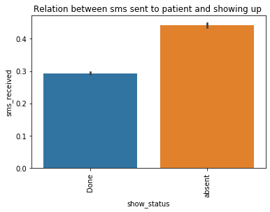

```python
df.groupby('show_status')['sms_received'].mean().plot(kind='bar',title='Relation between sms sent to patient and showing up ',color=['blue','red'],alpha=0.7);
plt.ylabel('No.of messages sent')
plt.xlabel('Show Status')
sns.barplot(data=df, x="show_status", y="sms_received");
```

### Q2: What gender is more prone to show up for the appointment?

**Calculating the perecentage who didn't go to the appointment for males and females then compare them in a bar graph**

```python
df_abs = df.query('show_status=="absent"')

gender_f = df_abs['gender'].value_counts()[0]
gender_f
```

```
14455
```

```python
total_f = df['gender'].value_counts()[0]
proportion_f= gender_f/total_f
proportion_f
```

```
0.2024056233897166
```

```python
gender_m = df_abs['gender'].value_counts()[1]
total_m = df['gender'].value_counts()[1]
proportion_m= gender_m/total_m
proportion_m
```

```
0.19864847303443794
```

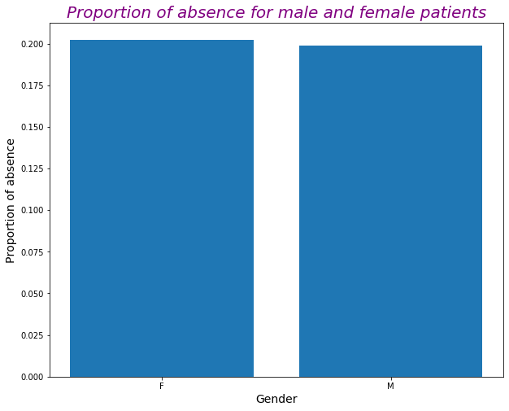

```python
plt.subplots(figsize=(10, 8))

plt.bar(["F", "M"], [proportion_f, proportion_m])
plt.title("Proportion of absence for male and female patients",fontsize=20, fontweight=0, color='purple', style='italic')
plt.xlabel("Gender",fontsize=14)
plt.ylabel("Proportion of absence",fontsize=14);
```

### Q3: What is the percentage of patients went to the appointment ?

```python
df.show_status.value_counts()
```

```
Done      87793
absent    22098
Name: show_status, dtype: int64
```

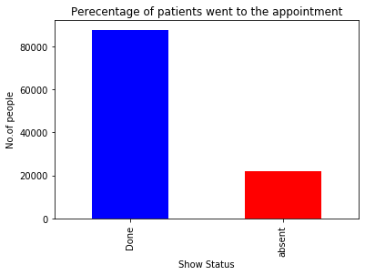

```python
df.show_status.value_counts().plot(kind='bar',title='Perecentage of patients went to the appointment',color=['blue','red'])
plt.ylabel('No.of people')
plt.xlabel('Show Status');
```

### Q4: Does the medical insurance affect the appearance of the patient for the appointment ?

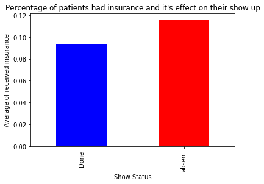

```python
df.groupby(['show_status'])['scholarship'].mean().plot(kind='bar',title="Percentage of patients had insurance and it's effect on their show up",color=['blue','red']);
plt.ylabel('Average of received insurance');
plt.xlabel('Show Status');
```

### Q5: Does the patient's age affect their appearance for the appointment, and what is the average age of the patients that didn't go to the appointmenmt?

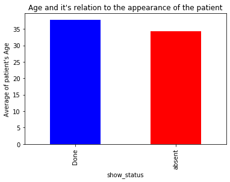

```python
df.groupby('show_status')['age'].mean().plot(kind='bar',title=("Age and it's relation to the appearance of the patient"),color=['blue','red'])
plt.ylabel("Average of patient's Age")
```

### Q6: Does any disease like diabetes may affect patient's appearance for the appointmemnt ?

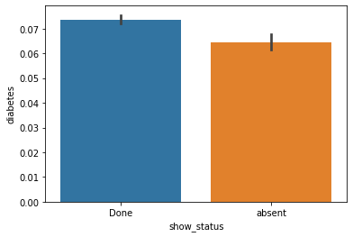

```python
sns.barplot(data=df, x="show_status", y="diabetes");
```

### Q7: Does The Location of the hospital affect the patient's showing up?

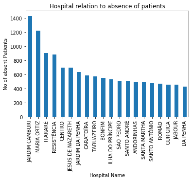

```python
df_abs = df.query('show_status=="absent"')

hos = df_abs['neighbourhood'].value_counts().head(20)
hos.plot(kind='bar',title='Hospital relation to absence of patients')
plt.ylabel('No of absent Patients')
plt.xlabel('Hospital Name');
```

### Q8: Which category has the most absence rate and which is most attendance?

**groupby age category with show status to determin which category did miss the appointment most and which is committed**

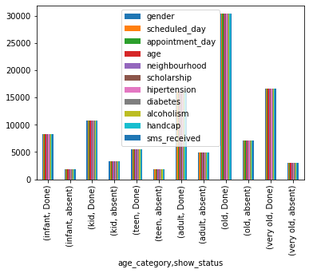

```python
df.groupby(['age_category','show_status']).count().plot(kind='bar');
```

**Then get the absence proprtion of each category**

```python
df['age_category'].value_counts()
```

```
old         37528
adult       21006
very old    19677
kid         14135
infant      10223
teen         7322
Name: age_category, dtype: int64
```

**Check the percentage of old patients who didn't show up for the appointment**

```python
total_old=df['age_category'].value_counts()[0]
total_old
```

```
37528
```

```python
absent = df.query('show_status == "absent"')
category_old = absent['age_category'].value_counts()[0]
category_old
```

```
7131
```

```python
proportion_old = category_old/total_old
proportion_old
```

```
0.19001811980387978
```

**Check the percentage of adult patients who didn't show up for the appointment**

```python
total_adult=df['age_category'].value_counts()[1]
category_adult = absent['age_category'].value_counts()[1]
proportion_adult = category_adult/total_adult
proportion_adult
```

```
0.2355517471198705
```

```python
total_very_old=df['age_category'].value_counts()[2]
category_very_old = absent['age_category'].value_counts()[2]
proportion_very_old = category_very_old/total_very_old
proportion_very_old
```

```
0.1704019921736037
```

```python
total_kid=df['age_category'].value_counts()[3]
category_kid = absent['age_category'].value_counts()[3]
proportion_kid = category_kid/total_kid
proportion_kid
```

```
0.21061195613724798
```

**Check the percentage of Infant patients who didn't show up for the appointment**

```python
total_infant=df['age_category'].value_counts()[4]
category_infant = absent['age_category'].value_counts()[4]
proportion_infant= category_infant/total_infant
proportion_infant
```

```
0.18174704098601194
```

**Check the percentage of Teen patients who didn't show up for the appointment**

```python
total_teen=df['age_category'].value_counts()[5]
category_teen = absent['age_category'].value_counts()[5]
proportion_teen = category_teen/total_teen
proportion_teen
```

```
0.2500682873531822
```

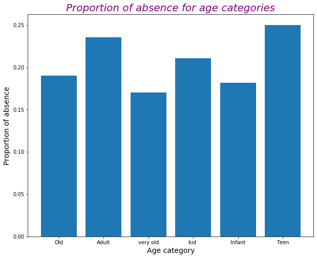

```python
plt.subplots(figsize=(10, 8))

plt.bar(["Old", "Adult","very old","kid ","Infant","Teen"], [proportion_old, proportion_adult,proportion_very_old,proportion_kid,proportion_infant,proportion_teen])
plt.title("Proportion of absence for age categories",fontsize=20, fontweight=0, color='purple', style='italic')
plt.xlabel("Age category",fontsize=14)
plt.ylabel("Proportion of absence",fontsize=14);
```

```python
df.head()
```

|  | gender | scheduled_day | appointment_day | age | neighbourhood | scholarship | hipertension | diabetes | alcoholism | handcap | sms_received | show_status | age_category |
| --- | --- | --- | --- | --- | --- | --- | --- | --- | --- | --- | --- | --- | --- |
| 0 | F | 2016-04-29 18:38:08 | 2016-04-29 | 62 | JARDIM DA PENHA | 0 | 1 | 0 | 0 | 0 | 0 | Done | very old |
| 1 | M | 2016-04-29 16:08:27 | 2016-04-29 | 56 | JARDIM DA PENHA | 0 | 0 | 0 | 0 | 0 | 0 | Done | old |
| 2 | F | 2016-04-29 16:19:04 | 2016-04-29 | 62 | MATA DA PRAIA | 0 | 0 | 0 | 0 | 0 | 0 | Done | very old |
| 3 | F | 2016-04-29 17:29:31 | 2016-04-29 | 8 | PONTAL DE CAMBURI | 0 | 0 | 0 | 0 | 0 | 0 | Done | kid |
| 4 | F | 2016-04-29 16:07:23 | 2016-04-29 | 56 | JARDIM DA PENHA | 0 | 1 | 1 | 0 | 0 | 0 | Done | old |

**Removing time values from scheduled_day and reconvert it to datetime**

```python
df['scheduled_day']= pd.to_datetime(df['scheduled_day']).dt.date
df['scheduled_day']= pd.to_datetime(df['scheduled_day'])
df.dtypes
```

```
gender                     object
scheduled_day      datetime64[ns]
appointment_day    datetime64[ns]
age                         int64
neighbourhood              object
scholarship                 int64
hipertension                int64
diabetes                    int64
alcoholism                  int64
handcap                     int64
sms_received                int64
show_status                object
age_category             category
dtype: object
```

**Create a new column to be the difference between scheduled and appointment days**

```python
df['difference']=df['appointment_day']-df['scheduled_day']
df.dtypes
```

```
gender                      object
scheduled_day       datetime64[ns]
appointment_day     datetime64[ns]
age                          int64
neighbourhood               object
scholarship                  int64
hipertension                 int64
diabetes                     int64
alcoholism                   int64
handcap                      int64
sms_received                 int64
show_status                 object
age_category              category
difference         timedelta64[ns]
dtype: object
```

**Convert difference column to int instead of datetime**

```python
df['difference'] = pd.to_numeric(df['difference'].dt.days, downcast='integer')
df.dtypes
```

```
gender                     object
scheduled_day      datetime64[ns]
appointment_day    datetime64[ns]
age                         int64
neighbourhood              object
scholarship                 int64
hipertension                int64
diabetes                    int64
alcoholism                  int64
handcap                     int64
sms_received                int64
show_status                object
age_category             category
difference                  int16
dtype: object
```

```python
df.head()
```

|  | gender | scheduled_day | appointment_day | age | neighbourhood | scholarship | hipertension | diabetes | alcoholism | handcap | sms_received | show_status | age_category | difference |
| --- | --- | --- | --- | --- | --- | --- | --- | --- | --- | --- | --- | --- | --- | --- |
| 0 | F | 2016-04-29 | 2016-04-29 | 62 | JARDIM DA PENHA | 0 | 1 | 0 | 0 | 0 | 0 | Done | very old | 0 |
| 1 | M | 2016-04-29 | 2016-04-29 | 56 | JARDIM DA PENHA | 0 | 0 | 0 | 0 | 0 | 0 | Done | old | 0 |
| 2 | F | 2016-04-29 | 2016-04-29 | 62 | MATA DA PRAIA | 0 | 0 | 0 | 0 | 0 | 0 | Done | very old | 0 |
| 3 | F | 2016-04-29 | 2016-04-29 | 8 | PONTAL DE CAMBURI | 0 | 0 | 0 | 0 | 0 | 0 | Done | kid | 0 |
| 4 | F | 2016-04-29 | 2016-04-29 | 56 | JARDIM DA PENHA | 0 | 1 | 1 | 0 | 0 | 0 | Done | old | 0 |

**Removing minus values in difference column**

```python
anomoly = df[(df['difference']<0)]

anomoly

df = df.drop([27033,55226,64175,71533,72362])
```

```python
df['difference']=df['difference'].astype(np.int64)
df.dtypes
```

```
gender                     object
scheduled_day      datetime64[ns]
appointment_day    datetime64[ns]
age                         int64
neighbourhood              object
scholarship                 int64
hipertension                int64
diabetes                    int64
alcoholism                  int64
handcap                     int64
sms_received                int64
show_status                object
age_category             category
difference                  int64
dtype: object
```

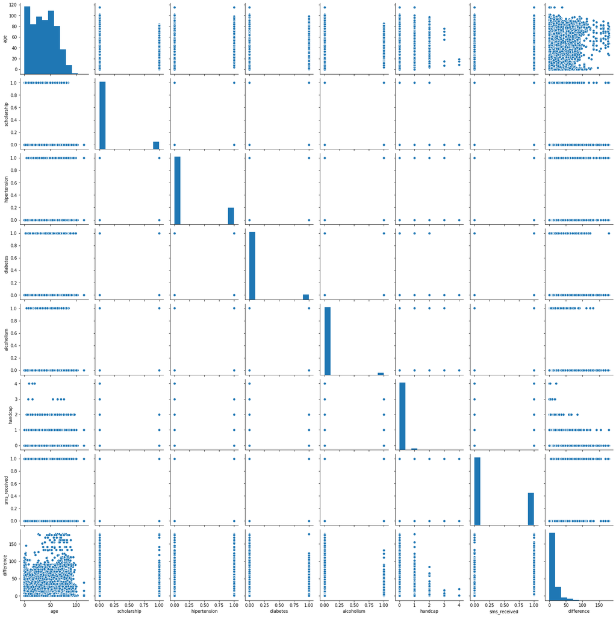

```python
sns.pairplot(df)
```

### Q9: What is the relation between days difference and show status?

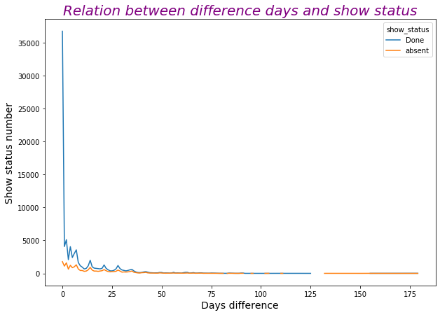

```python
fig, ax = plt.subplots(figsize=(10,7))

df.groupby('difference')['show_status'].value_counts().unstack().plot(ax=ax);
plt.title('Relation between difference days and show status',fontsize=20, fontweight=0, color='purple', style='italic')
plt.xlabel('Days difference',fontsize=14)
plt.ylabel('Show status number',fontsize=14)
```

## Conclusions

**From data wrangling part we found out that we have 2 cloumns that wouldn't be necessary to be involved in the analysis. by checking the dytpes we found out that schedueled day and appointment day are objects, so we needed to convert them to datetime.**

**After some wrangling we found that we have duplicates we did remove them from the dataset, and no NaN values found**

**Then we started some cleaning by dropping (ID pateint, Appointment ID), then converted all headers to lower case and add some under_scores to some of them.**

**No show column was represnted if yes means,that patient didn't go to the appointment, and if no means that the patient did go to the appointment, so we changed the column meaning itself to be show status if yes means done if no means absent**

**We found a minus value in age column we did remove it**

**After that we created a new column called difference which is the difference between scheduled and appointment dates**

**Creating a plot to show the relation between days difference and show status**

**We did groupby some cloumns together, we found out:**

1. There is no relation between alcohol and show_status
2. 80% of patients are committed to the appointment Q3
3. Patients who didn't go to the appointments being sent SMS of the appointments more than patients who did go to the appointment. Q1
4. Female patients are more prone to miss the appoinment than males regarldless their age. Q2
5. Scholraship or (insurance) doesn't show a big effect on people who received scholraship to show up for the appointment Q4
6. elder patients are more committed to show up for the appointment Q5
7. Diseased patients like with diabetes are more commited to the hospital's appointment Q6
8. Two hospital locations have the highest rate of patient's absence (JORDIM CAMBURI) and (MARIA ORTIZ) Q7
9. Very old patients who has more than 60 years old are more commited to the appointment time.However, Teens has the most rate of absence. Q8

```python
df.to_csv('new patient.csv',index=False)
```

```python
data = pd.read_csv('new patient.csv')
data.head()
```

|  | gender | scheduled_day | appointment_day | age | neighbourhood | scholarship | hipertension | diabetes | alcoholism | handcap | sms_received | show_status | age_category | difference |
| --- | --- | --- | --- | --- | --- | --- | --- | --- | --- | --- | --- | --- | --- | --- |
| 0 | F | 2016-04-29 | 2016-04-29 | 62 | JARDIM DA PENHA | 0 | 1 | 0 | 0 | 0 | 0 | Done | very old | 0 |
| 1 | M | 2016-04-29 | 2016-04-29 | 56 | JARDIM DA PENHA | 0 | 0 | 0 | 0 | 0 | 0 | Done | old | 0 |
| 2 | F | 2016-04-29 | 2016-04-29 | 62 | MATA DA PRAIA | 0 | 0 | 0 | 0 | 0 | 0 | Done | very old | 0 |
| 3 | F | 2016-04-29 | 2016-04-29 | 8 | PONTAL DE CAMBURI | 0 | 0 | 0 | 0 | 0 | 0 | Done | kid | 0 |
| 4 | F | 2016-04-29 | 2016-04-29 | 56 | JARDIM DA PENHA | 0 | 1 | 1 | 0 | 0 | 0 | Done | old | 0 |